# Does Unemployment Increase During Recessions?

This notebook tests whether the US unemployment rate is higher, and rises faster, during NBER-dated recessions than during expansions.

**Expectation:** Yes. During economic downturns, firms hire less and lay off more workers, so unemployment should rise.

The analysis covers January 2000 to the present, using monthly data from FRED.

## Setup

The libraries used in this notebook:

- **fredapi** pulls series directly from the FRED API.
- **python-dotenv** loads the FRED API key from a local `.env` file. The file is listed in `.gitignore`, so the key never enters the repo.
- **pandas** cleans and merges the data.
- **matplotlib** draws the charts.
- **statsmodels** runs the regressions.

```python
import os

import matplotlib.pyplot as plt
import pandas as pd
import statsmodels.formula.api as smf
from dotenv import load_dotenv
from fredapi import Fred
```

## Data Pull

Two monthly series come from FRED:

| Series ID | Description | Original source |
| --- | --- | --- |
| `UNRATE` | Civilian unemployment rate (%) | Bureau of Labor Statistics |
| `USREC` | Recession indicator (1 = recession month, 0 = not) | National Bureau of Economic Research |

The pull starts at 1999-12-01, one month before the analysis window. That extra month means the monthly change in unemployment can be computed for January 2000.

```python
# Read the key from .env rather than hard-coding it, so it stays out of the repo.
load_dotenv()
api_key = os.getenv("FRED_API_KEY")
if not api_key:
    raise RuntimeError("FRED_API_KEY not found; add it to the .env file in this folder.")

fred = Fred(api_key=api_key)

START = "1999-12-01"
unrate = fred.get_series("UNRATE", observation_start=START).rename("UNRATE")
usrec = fred.get_series("USREC", observation_start=START).rename("USREC")
```

```python
display(unrate.head())
display(usrec.head())
```

```
1999-12-01    4.0
2000-01-01    4.0
2000-02-01    4.1
2000-03-01    4.0
2000-04-01    3.8
Name: UNRATE, dtype: float64
```

```
1999-12-01    0.0
2000-01-01    0.0
2000-02-01    0.0
2000-03-01    0.0
2000-04-01    0.0
Name: USREC, dtype: float64
```

## Cleaning

The cleaning steps follow the plan:

1. **Merge** UNRATE and USREC into one DataFrame on date.
2. **Compute the monthly change** in the unemployment rate (this month minus last month).
3. **Drop months** where either series is missing.
4. **Convert the recession indicator** to 0/1 integers (FRED returns it as 0.0/1.0).
5. **Restrict** the data to January 2000 onward.

The change is computed on a complete monthly calendar *before* missing months are dropped. FRED has no unemployment value for October 2025 (the government shutdown delayed that month's survey). Computing the change after dropping it would make November 2025's "monthly" change span two months. Computing it first leaves November's change blank, and the averages below skip it. The extra December 1999 month from the pull is used only to compute January 2000's change.

```python
# asfreq("MS") lays the data on a full month-start calendar, so a missing month
# shows up as a gap that diff() won't bridge.
df = pd.concat([unrate, usrec], axis=1).asfreq("MS")
df["UNRATE_CHANGE"] = df["UNRATE"].diff()

df = df.dropna(subset=["UNRATE", "USREC"])
df["USREC"] = df["USREC"].astype(int)
df = df.loc["2000-01-01":]

print(f"{len(df)} months, {df.index.min():%Y-%m} to {df.index.max():%Y-%m}")
df.head()
```

```
319 months, 2000-01 to 2026-08
```

|  | UNRATE | USREC | UNRATE_CHANGE |
| --- | --- | --- | --- |
| 2000-01-01 | 4.0 | 0 | 0.0 |
| 2000-02-01 | 4.1 | 0 | 0.1 |
| 2000-03-01 | 4.0 | 0 | -0.1 |
| 2000-04-01 | 3.8 | 0 | -0.2 |
| 2000-05-01 | 4.0 | 0 | 0.2 |

```python
summary = (
    df.groupby("USREC")
    .agg(
        months=("UNRATE", "size"),
        avg_unemployment_rate=("UNRATE", "mean"),
        avg_monthly_change=("UNRATE_CHANGE", "mean"),
    )
    .rename(index={0: "Expansion", 1: "Recession"})
    .rename_axis("Period")
)
summary.round(2)
```

| Period | months | avg_unemployment_rate | avg_monthly_change |
| --- | --- | --- | --- |
| Expansion | 291 | 5.53 | -0.06 |
| Recession | 28 | 6.43 | 0.61 |

Since 2000, the average unemployment rate during recession months (about 6.4%) has been roughly a percentage point higher than during expansion months (about 5.5%). The monthly change shows the bigger difference: during recessions unemployment rose by about 0.6 points per month on average, while during expansions it fell slightly (about −0.06 points per month).

This supports the expectation. The averages also come from only 28 recession months across three recessions (2001, 2007–09 and 2020). The 2020 COVID spike, when unemployment jumped about 10 points in a single month, pulls the recession average up a lot. The regressions later in the notebook test whether these differences are statistically significant.

## Charts

Three charts show the relationship visually:

1. **Unemployment rate over time** with recession months shaded gray. This shows whether unemployment climbs during each recession.
2. **Average unemployment rate** in recessions vs. expansions. This compares the *level*.
3. **Average monthly change in unemployment** in recessions vs. expansions. This compares the *direction*: whether unemployment rises or falls.

A small helper adds the title, axis labels and source note, so every chart is labeled the same way.

```python
LINE_COLOR = "#2a78d6"
SOURCE_NOTE = "Source: BLS and NBER via FRED."


def label_chart(ax, title, xlabel, ylabel):
    """Apply the title, axis labels and source note every chart in this notebook needs."""
    ax.set_title(title, loc="left", fontsize=13, fontweight="bold")
    ax.set_xlabel(xlabel)
    ax.set_ylabel(ylabel)
    # Keep the axes and grid quiet so the data stands out.
    ax.spines[["top", "right"]].set_visible(False)
    ax.grid(axis="y", color="#e6e5e1", linewidth=0.8)
    ax.set_axisbelow(True)
    # Place the note in axes coordinates so it sits below the x-axis label at any figure size.
    ax.annotate(SOURCE_NOTE, xy=(0, -0.18), xycoords="axes fraction",
                fontsize=9, color="#52514e", va="top")


def label_bars(ax, bars, fmt):
    """Print each bar's value at its tip; negative bars get the label below."""
    for bar in bars:
        height = bar.get_height()
        ax.annotate(fmt.format(height),
                    xy=(bar.get_x() + bar.get_width() / 2, height),
                    xytext=(0, 4 if height >= 0 else -4), textcoords="offset points",
                    ha="center", va="bottom" if height >= 0 else "top", fontsize=10)
```

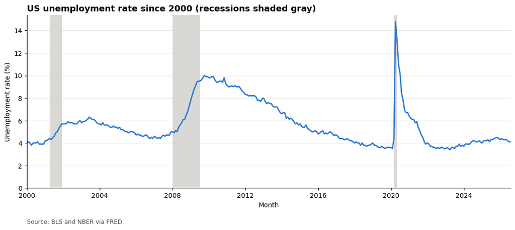

```python
fig, ax = plt.subplots(figsize=(11, 5))

# Shade each recession month as its own span; adjacent months merge into one block.
for month in df.index[df["USREC"] == 1]:
    ax.axvspan(month, month + pd.offsets.MonthBegin(1), color="#d9d8d4", linewidth=0)

ax.plot(df.index, df["UNRATE"], color=LINE_COLOR, linewidth=2)
ax.set_ylim(bottom=0)
ax.set_xlim(df.index.min(), df.index.max())

label_chart(ax, "US unemployment rate since 2000 (recessions shaded gray)",
            "Month", "Unemployment rate (%)")
plt.tight_layout()
plt.show()
```

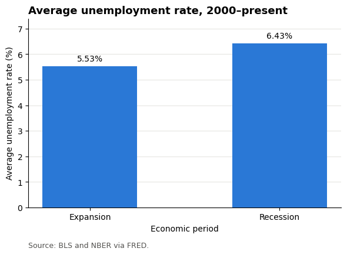

```python
fig, ax = plt.subplots(figsize=(6, 4.5))
bars = ax.bar(summary.index, summary["avg_unemployment_rate"], color=LINE_COLOR, width=0.5)
label_bars(ax, bars, "{:.2f}%")
ax.set_ylim(0, summary["avg_unemployment_rate"].max() * 1.15)

label_chart(ax, "Average unemployment rate, 2000–present",
            "Economic period", "Average unemployment rate (%)")
plt.tight_layout()
plt.show()
```

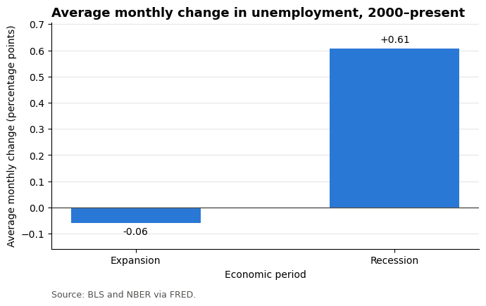

```python
fig, ax = plt.subplots(figsize=(7, 4.5))
bars = ax.bar(summary.index, summary["avg_monthly_change"], color=LINE_COLOR, width=0.5)
label_bars(ax, bars, "{:+.2f}")
# A zero line makes it clear which bar is a rise and which is a fall.
ax.axhline(0, color="#52514e", linewidth=1)
# Pad both ends by a share of the full range so the value labels fit inside the axes.
low, high = summary["avg_monthly_change"].min(), summary["avg_monthly_change"].max()
pad = 0.15 * (max(high, 0) - min(low, 0))
ax.set_ylim(min(low, 0) - pad, max(high, 0) + pad)

label_chart(ax, "Average monthly change in unemployment, 2000–present",
            "Economic period", "Average monthly change (percentage points)")
plt.tight_layout()
plt.show()
```

**What the charts show:**

- **Line chart.** Unemployment climbs during or right after each of the three recessions since 2000 (2001, 2007–09 and 2020), then falls slowly through the expansions that follow. The 2020 recession is short but produces by far the largest spike. After the 2001 and 2007–09 recessions, unemployment kept rising for a while after the shaded period ended. Unemployment tends to lag the business cycle, which helps explain why the gap in average levels is smaller than the peaks suggest.
- **Average level.** Unemployment averaged about 6.4% in recession months vs. about 5.5% in expansion months.
- **Average monthly change.** This shows the clearest difference. Unemployment rose about 0.6 points per month during recessions and fell slightly during expansions.

Together, the charts support the expectation that unemployment rises during recessions. The regressions will test whether the differences are statistically significant.

## Regressions

Two simple regressions from the plan, each with the recession indicator (`USREC`, 1 = recession month) as the only explanatory variable:

1. **Level:** Unemployment Rate = β0 + β1(Recession Indicator)
2. **Change:** Change in Unemployment Rate = β0 + β1(Recession Indicator)

In each, β0 is the average for expansion months, and β1 is how much higher the average is in recession months. A positive, statistically significant β1 supports the expectation. The second regression tests whether unemployment actually *rises faster* during recessions, not just whether it is higher.

**Standard errors:** Both use Newey-West (HAC) standard errors with 12 lags. Unemployment this month is closely tied to unemployment in recent months, so ordinary standard errors would treat 319 connected months as 319 independent data points and overstate the precision. Twelve lags lets errors be correlated across up to a year, a common choice for monthly data.

**Robustness check:** Both regressions are run again without March and April 2020. In April 2020 unemployment jumped 10.4 points, the largest one-month move in the data, and a single outlier like that can drive a regression on its own. March and April 2020 are the *only* recession months NBER assigns to 2020, so this check also removes the 2020 recession entirely.

```python
COVID_MONTHS = pd.to_datetime(["2020-03-01", "2020-04-01"])
HAC_LAGS = 12

samples = {
    "Full sample": df,
    "Excluding Mar–Apr 2020": df.drop(COVID_MONTHS),
}
outcomes = {
    "Unemployment rate (%)": "UNRATE",
    "Monthly change (pct. points)": "UNRATE_CHANGE",
}

rows = []
models = {}
for sample_name, data in samples.items():
    for outcome_name, column in outcomes.items():
        # missing="drop" skips Nov 2025, whose change is blank because Oct 2025 is missing.
        model = smf.ols(f"{column} ~ USREC", data=data, missing="drop").fit(
            cov_type="HAC", cov_kwds={"maxlags": HAC_LAGS}
        )
        models[(sample_name, outcome_name)] = model
        rows.append({
            "Outcome": outcome_name,
            "Sample": sample_name,
            "Months": int(model.nobs),
            "β1 (recession effect)": model.params["USREC"],
            "p-value": model.pvalues["USREC"],
        })

results = pd.DataFrame(rows).set_index(["Outcome", "Sample"])
results.style.format({"β1 (recession effect)": "{:+.3f}", "p-value": "{:.4f}"})
```

| Outcome | Sample | Months | β1 (recession effect) | p-value |
| --- | --- | --- | --- | --- |
| Unemployment rate (%) | Full sample | 319 | +0.898 | 0.2188 |
| Monthly change (pct. points) | Full sample | 318 | +0.666 | 0.1246 |
| Unemployment rate (%) | Excluding Mar–Apr 2020 | 317 | +0.654 | 0.3817 |
| Monthly change (pct. points) | Excluding Mar–Apr 2020 | 316 | +0.278 | 0.0000 |

```python
# Full output for the two main regressions, for reference.
for outcome_name in outcomes:
    print(f"=== {outcome_name}, full sample ===")
    print(models[("Full sample", outcome_name)].summary().tables[1], end="\n\n")
```

```
=== Unemployment rate (%), full sample ===
==============================================================================
                 coef    std err          z      P>|z|      [0.025      0.975]
------------------------------------------------------------------------------
Intercept      5.5306      0.360     15.369      0.000       4.825       6.236
USREC          0.8980      0.730      1.230      0.219      -0.533       2.329
==============================================================================

=== Monthly change (pct. points), full sample ===
==============================================================================
                 coef    std err          z      P>|z|      [0.025      0.975]
------------------------------------------------------------------------------
Intercept     -0.0586      0.028     -2.116      0.034      -0.113      -0.004
USREC          0.6658      0.434      1.536      0.125      -0.184       1.515
==============================================================================
```

**What the regressions show:**

- **Level of unemployment (Regression 1).** The unemployment rate averages about 0.9 points higher in recession months (β1 ≈ +0.90). With HAC standard errors that difference is **not statistically significant** (p ≈ 0.22), and it shrinks to about +0.65 (p ≈ 0.38) without March–April 2020. Unemployment moves slowly and keeps rising after recessions end, so recession and expansion months overlap a lot in their *levels*. Long stretches of high unemployment, like 2009–2012, fall in expansion months.
- **Change in unemployment (Regression 2).** Unemployment rises about 0.67 points per month faster in recessions than in expansions (β1 ≈ +0.67). In the full sample this is not significant (p ≈ 0.12). The April 2020 jump is so extreme that it makes the estimate very noisy. Without March–April 2020, the effect is smaller (about +0.28 points per month) but **highly significant** (p < 0.001).

**Bottom line:** The evidence partly supports the expectation. Recessions are not clearly associated with a higher *level* of unemployment, once you account for how slowly unemployment moves. They are associated with unemployment *rising faster*, and that finding is strongest once the single COVID outlier is set aside. The positive β1 in every specification points the same way, but with only three recessions and 28 recession months since 2000, the estimates are imprecise. As the plan notes, this is a correlation, not proof that recessions cause the rise.

## Conclusion

The clearer results is the change in speed of how unemployment changes as during recessions it rose around 0.67 points per month faster than during expansion periods.

Did it match my expecatation: Yes, partially. I expected the rise in unemployment during recessions to be stastically significant and the results support that for the change in unemployment. But, the level result is weaker.

Some of the limitations were:

- Only 3 recessions have occured since 2000
- Removing March and April 20202 drops the entire 2020 recession
- This shows correlation and not causation.
- Unemployment usually lags behind the business cycle.